[figure not shown]

# CSC 587 HW 4

Daniel R. Getty

2024-04-22

## Homework 4

1. Given a data tuple having the values ”systems”, ”26_30”, and ”46K_50K” for the attributes department, age, and salary, respectively, what would a naive Bayesian classification of the status according to the data above? Notice that Count column is NOT an attribute. It just tells how many times a row occurs in our database and status is our target variable.

```python
# create a data frame
data = {'department': ['sales', 'sales', 'sales', 'systems', 'systems', 'systems', 'systems', 'marketing', 'marketing', 'secretary', 'secretary'],'age': ['31_35', '26_30', '31_35', '21_25', '31_35', '26_30', '41_45', '36_40', '31_35', '46_50', '26_30'],'salary': ['46K_50K', '26K_30K', '31K_35K', '46K_50K', '66K_70K', '46K_50K', '66K_70K', '46K_50K', '41K_45K', '36K_40K', '26K_30K'], 'status': ['senior', 'junior', 'junior', 'junior', 'senior', 'junior', 'senior', 'senior', 'junior', 'senior', 'junior'],'count': [30, 40, 40, 20, 5, 3, 3, 10, 4, 4, 6]}

df = pd.DataFrame(data)
print(df.to_markdown(tablefmt="grid"))
```

department

age

salary

status

count

0

sales

31_35

46K_50K

senior

```
 30
```

1

sales

26_30

26K_30K

junior

```
 40
```

2

sales

31_35

31K_35K

junior

```
 40
```

3

systems

21_25

46K_50K

junior

```
 20
```

4

systems

31_35

66K_70K

senior

```
  5
```

5

systems

26_30

46K_50K

junior

```
  3
```

6

systems

41_45

66K_70K

senior

```
  3
```

7

marketing

36_40

46K_50K

senior

```
 10
```

8

marketing

31_35

41K_45K

junior

```
  4
```

9

secretary

46_50

36K_40K

senior

```
  4
```

10

secretary

26_30

26K_30K

junior

```
  6
```

```python
# df.head()
# print (df)

# calculate the probability of each status
sum_total = sum(df['count'])
print("Total:",sum_total)
```

Total: 165

```python
senior_total = sum(df['count'][df['status'] == 'senior'])
print("Senior Total:",senior_total)
```

Senior Total: 52

```python
junior_total = sum(df['count'][df['status'] == 'junior'])
print("Junior Total:",junior_total)
```

Junior Total: 113

```python
PStatus_Senior = (senior_total / sum_total)

print("P(Staus = Senior)",round(PStatus_Senior,2))
```

P(Staus = Senior) 0.32

```python
PStatus_Junior = (junior_total / sum_total)

print("P(Staus = Junior)",round(PStatus_Junior,2))
```

P(Staus = Junior) 0.68

```python
# calculate the probability of systems department
systems_total = sum(df['count'][df['department'] == 'systems'])
print("Department Total:",systems_total)
```

Department Total: 31

```python
PDept_Systems = (systems_total / sum_total)
print("P(Department = Systems)",round(PDept_Systems,2))
```

P(Department = Systems) 0.19

```python
# calculate the probability of age 26_30
age_total = sum(df['count'][df['age'] == '26_30'])
print("Age Total:",age_total)
```

Age Total: 49

```python
PAge_26_30 = (age_total / sum_total)
print("P(Age = 26_30)",round(PAge_26_30,2))
```

P(Age = 26_30) 0.3

```python
# calculate the probability of salary 46K_50K
salary_total = sum(df['count'][df['salary'] == '46K_50K'])
print("Salary Total:",salary_total)
```

Salary Total: 63

```python
PSalary_46K_50K = (salary_total / sum_total)
print("P(Salary = 46K_50K)",round(PSalary_46K_50K,2))
```

P(Salary = 46K_50K) 0.38

```python
# calculate the probability of status senior given department systems, age 26_30, and salary 46K_50K
PStatus_Senior_x = (PDept_Systems * PAge_26_30 * PSalary_46K_50K * PStatus_Senior * PStatus_Senior)
print("P(Status = Senior | Department = Systems, Age = 26_30, Salary = 46K_50K)",round(PStatus_Senior_x,2))
```

P(Status = Senior | Department = Systems, Age = 26_30, Salary = 46K_50K) 0.0

```python
# calculate the probability of status junior given department systems, age 26_30, and salary 46K_50K
PStatus_Junior_x = (PDept_Systems * PAge_26_30 * PSalary_46K_50K * PStatus_Junior * PStatus_Junior)
print("P(Status = Junior | Department = Systems, Age = 26_30, Salary = 46K_50K)",round(PStatus_Junior_x,2))
```

P(Status = Junior | Department = Systems, Age = 26_30, Salary = 46K_50K) 0.01

2. split your diabetes data into two parts for training and testing purposes. Namely, reserve last 10 rows of the diabetes_train.csv for the test set. Then fit a SVM classifier on the bigger portion of this data and test it on these 10 rows you had reserved. Please feel free to modify existing codes. Notice that you’re not going to read diabetes_test.csv anymore since you’re going to split the bigger data. Please submit your Python code and your prediction results

```python
# read the diabetes data
diabetes = pd.read_csv('diabetes_train.csv')

# split the data into training and testing reserves last 10 rows for testing
test = diabetes.iloc[-10:]
train = diabetes.iloc[:-10]

print("Test Data")
```

Test Data

```python
print(test.to_markdown(tablefmt="grid"))
```

preg

plas

pres

skin

insu

mass

pedi

age

class

748

```
 3
```

187

```
70
```

```
22
```

200

36.4

0.408

36

tested_positive

749

```
 6
```

162

```
62
```

```
 0
```

```
 0
```

24.3

0.178

50

tested_positive

750

```
 4
```

136

```
70
```

```
 0
```

```
 0
```

31.2

1.182

22

tested_positive

751

```
 1
```

121

```
78
```

```
39
```

```
74
```

39

0.261

28

tested_negative

752

```
 3
```

108

```
62
```

```
24
```

```
 0
```

26

0.223

25

tested_negative

753

```
 0
```

181

```
88
```

```
44
```

510

43.3

0.222

26

tested_positive

754

```
 8
```

154

```
78
```

```
32
```

```
 0
```

32.4

0.443

45

tested_positive

755

```
 1
```

128

```
88
```

```
39
```

110

36.5

1.057

37

tested_positive

756

```
 7
```

137

```
90
```

```
41
```

```
 0
```

32

0.391

39

tested_negative

757

```
 0
```

123

```
72
```

```
 0
```

```
 0
```

36.3

0.258

52

tested_positive

```python
print("\n")
```

```python
print("Train Data")
```

Train Data

```python
dfhead = train.head()
print(dfhead.to_markdown(tablefmt="grid"))
```

preg

plas

pres

skin

insu

mass

pedi

age

class

0

```
 6
```

148

```
72
```

```
35
```

```
 0
```

33.6

0.627

50

tested_positive

1

```
 1
```

```
85
```

```
66
```

```
29
```

```
 0
```

26.6

0.351

31

tested_negative

2

```
 8
```

183

```
64
```

```
 0
```

```
 0
```

23.3

0.672

32

tested_positive

3

```
 1
```

```
89
```

```
66
```

```
23
```

```
94
```

28.1

0.167

21

tested_negative

4

```
 0
```

137

```
40
```

```
35
```

168

43.1

2.288

33

tested_positive

```python
print("\n")
```

```python
# print(train.to_markdown(tablefmt="grid"))

# fit a SVM classifier
from sklearn import svm
clf = svm.SVC()
clf.fit(train.iloc[:,:-1], train.iloc[:,-1])
```

```
SVC()
```

```python
# test the classifier
prediction = clf.predict(test.iloc[:,:-1])
prediction = pd.DataFrame(prediction, columns=['Prediction'])
# print the prediction results
# print("Predicted Results =",prediction)
print(prediction.to_markdown())
```

|  | Prediction |
| --- | --- |
| 0 | tested_positive |
| 1 | tested_positive |
| 2 | tested_negative |
| 3 | tested_negative |
| 4 | tested_negative |
| 5 | tested_positive |
| 6 | tested_positive |
| 7 | tested_negative |
| 8 | tested_negative |
| 9 | tested_negative |

```python
# create a data frame
classes = ['a','b','c','d','e','f','g','h']
data = {'x1': [2, 2, 8, 5, 7, 6, 1, 4],'x2': [10, 5, 4, 8, 5, 4, 2, 9]}
P3_df = pd.DataFrame(data, index=classes)
# print(P3_df)
print(P3_df.to_markdown(tablefmt="grid"))
```

|  | x1 | x2 |
| --- | --- | --- |
| a | 2 | 10 |
| b | 2 | 5 |
| c | 8 | 4 |
| d | 5 | 8 |
| e | 7 | 5 |
| f | 6 | 4 |
| g | 1 | 2 |
| h | 4 | 9 |

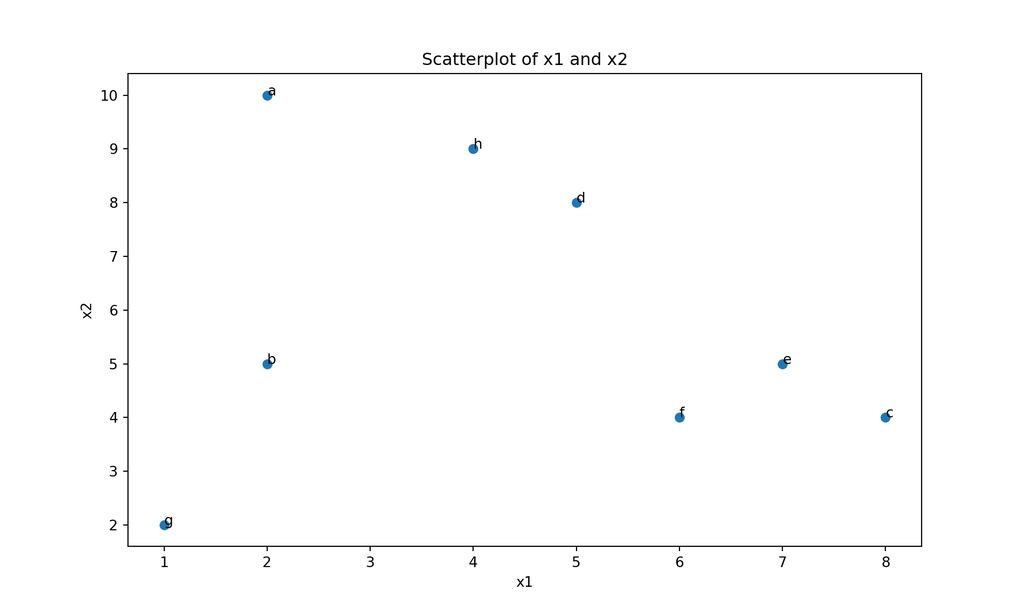

```python
# build a scatterplot of the df
plt.figure(figsize=(10, 6))
plt.scatter(P3_df['x1'], P3_df['x2'])
plt.xlabel('x1')
plt.ylabel('x2')
plt.title('Scatterplot of x1 and x2')
for i, txt in enumerate(classes):
    plt.annotate(txt, (P3_df['x1'][i], P3_df['x2'][i]))

plt.show()
```

(a) If h and c are selected as the initial centers for your k-means clustering, assign memberships for other points, and compute the means (centroids) of your initial clusters. You can use Manhattan distance.

```python
# initial centers
c1 = P3_df.loc['h']
c2 = P3_df.loc['c']
print(c1)
```

x1 4 x2 9 Name: h, dtype: int64

```python
print(c2)
```

x1 8 x2 4 Name: c, dtype: int64

```python
# assign memberships using manhattan distance

P3_df['d_c1'] = np.abs(P3_df['x1'] - c1['x1']) + np.abs(P3_df['x2'] - c1['x2'])
P3_df['d_c2'] = np.abs(P3_df['x1'] - c2['x1']) + np.abs(P3_df['x2'] - c2['x2'])
P3_df['mem'] = np.where(P3_df['d_c1'] < P3_df['d_c2'], 'c1', 'c2')

# P3_df['d_c1'] = np.sqrt((P3_df['x1'] - c1['x1'])**2 + (P3_df['x2'] - c1['x2'])**2)
# P3_df['d_c2'] = np.sqrt((P3_df['x1'] - c2['x1'])**2 + (P3_df['x2'] - c2['x2'])**2)
# P3_df['mem'] = np.where(P3_df['d_c1'] < P3_df['d_c2'], 'c1', 'c2')

# print(P3_df)
print(P3_df.to_markdown(tablefmt="grid"))
```

x1

x2

d_c1

d_c2

mem

a

2

10

```
 3
```

```
12
```

c1

b

2

5

```
 6
```

```
 7
```

c1

c

8

4

```
 9
```

```
 0
```

c2

d

5

8

```
 2
```

```
 7
```

c1

e

7

5

```
 7
```

```
 2
```

c2

f

6

4

```
 7
```

```
 2
```

c2

g

1

2

```
10
```

```
 9
```

c2

h

4

9

```
 0
```

```
 9
```

c1

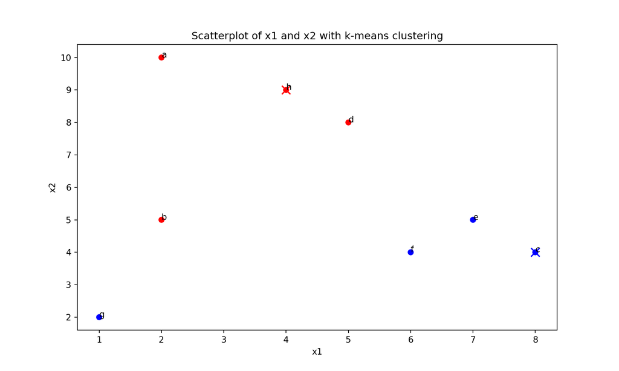

```python
# build a visualization of the k-means clustering
plt.figure(figsize=(10, 6))
plt.scatter(P3_df['x1'], P3_df['x2'], c=P3_df['mem'].map({'c1': 'red', 'c2': 'blue'}))
plt.scatter(c1['x1'], c1['x2'], color='red', marker='x', s=100)
plt.scatter(c2['x1'], c2['x2'], color='blue', marker='x', s=100)
plt.xlabel('x1')
plt.ylabel('x2')
plt.title('Scatterplot of x1 and x2 with k-means clustering')
for i, txt in enumerate(classes):
    plt.annotate(txt, (P3_df['x1'][i], P3_df['x2'][i]))

plt.show()
```

2. Based on the centroids you found above reassign the memberships by using Manhattan distance

```python
# reassign memberships
c1 = P3_df[P3_df['mem'] == 'c1'][['x1', 'x2']].mean()
c2 = P3_df[P3_df['mem'] == 'c2'][['x1', 'x2']].mean()

P3_df['d_c1'] = np.abs(P3_df['x1'] - c1['x1']) + np.abs(P3_df['x2'] - c1['x2'])
P3_df['d_c2'] = np.abs(P3_df['x1'] - c2['x1']) + np.abs(P3_df['x2'] - c2['x2'])
P3_df['mem'] = np.where(P3_df['d_c1'] < P3_df['d_c2'], 'c1', 'c2')

# P3_df['d_c1'] = np.sqrt((P3_df['x1'] - c1['x1'])**2 + (P3_df['x2'] - c1['x2'])**2)
# P3_df['d_c2'] = np.sqrt((P3_df['x1'] - c2['x1'])**2 + (P3_df['x2'] - c2['x2'])**2)
# P3_df['mem'] = np.where(P3_df['d_c1'] < P3_df['d_c2'], 'c1', 'c2')

# print(P3_df)
print(P3_df.to_markdown(tablefmt="grid"))
```

|  | x1 | x2 | d_c1 | d_c2 | mem |
| --- | --- | --- | --- | --- | --- |
| a | 2 | 10 | 3.25 | 9.75 | c1 |
| b | 2 | 5 | 4.25 | 4.75 | c1 |
| c | 8 | 4 | 8.75 | 2.75 | c2 |
| d | 5 | 8 | 1.75 | 4.75 | c1 |
| e | 7 | 5 | 6.75 | 2.75 | c2 |
| f | 6 | 4 | 6.75 | 0.75 | c2 |
| g | 1 | 2 | 8.25 | 6.25 | c2 |
| h | 4 | 9 | 1.75 | 6.75 | c1 |

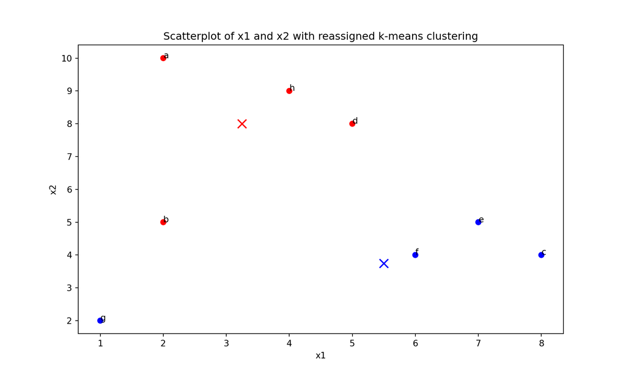

```python
# build a visualization of the reassigned k-means clustering
plt.figure(figsize=(10, 6))
plt.scatter(P3_df['x1'], P3_df['x2'], c=P3_df['mem'].map({'c1': 'red', 'c2': 'blue'}))
plt.scatter(c1['x1'], c1['x2'], color='red', marker='x', s=100)
plt.scatter(c2['x1'], c2['x2'], color='blue', marker='x', s=100)
plt.xlabel('x1')
plt.ylabel('x2')
plt.title('Scatterplot of x1 and x2 with reassigned k-means clustering')
for i, txt in enumerate(classes):
    plt.annotate(txt, (P3_df['x1'][i], P3_df['x2'][i]))

plt.show()
```

4. Given the distance matrix below answer the following questions. Notice that this is a distance matrix, meaning the distance between any pair of points can be found by checking the corresponding cell.

```python
# create a data frame
classes = ['b','c','d','e','f','g','h']
data = {'a': [5, 8, 4, 7, 7, 8, 2],'b': [0, 6, 4, 5, 4, 3, 4],'c': [0, 0, 5, 1, 2, 7, 6],'d': [0, 0, 0, 4, 4, 7, 1],'e': [0,0, 0, 0, 1, 7, 5],'f': [0, 0, 0, 0, 0, 5, 5],'g': [0, 0, 0, 0, 0, 0, 8]}
P4_df = pd.DataFrame(data, index=classes)
# print(P4_df)
print(P4_df.to_markdown(tablefmt="grid"))
```

|  | a | b | c | d | e | f | g |
| --- | --- | --- | --- | --- | --- | --- | --- |
| b | 5 | 0 | 0 | 0 | 0 | 0 | 0 |
| c | 8 | 6 | 0 | 0 | 0 | 0 | 0 |
| d | 4 | 4 | 5 | 0 | 0 | 0 | 0 |
| e | 7 | 5 | 1 | 4 | 0 | 0 | 0 |
| f | 7 | 4 | 2 | 4 | 1 | 0 | 0 |
| g | 8 | 3 | 7 | 7 | 7 | 5 | 0 |
| h | 2 | 4 | 6 | 1 | 5 | 5 | 8 |

1. Apply the hierarchical clustering algorithm with single linkage to the data above. Draw the final dendrogram.

```python
# apply hierarchical clustering with single linkage
from scipy.cluster.hierarchy import linkage, dendrogram
Z = linkage(P4_df, 'single')
plt.figure(figsize=(10, 6))
dendrogram(Z, p=30, truncate_mode=None, color_threshold=None, get_leaves=True, orientation='top', labels=classes, count_sort=False, distance_sort=False, show_leaf_counts=True, no_plot=False, no_labels=False, leaf_font_size=None, leaf_rotation=None, leaf_label_func=None, show_contracted=False, link_color_func=None, ax=None, above_threshold_color='C0')
```

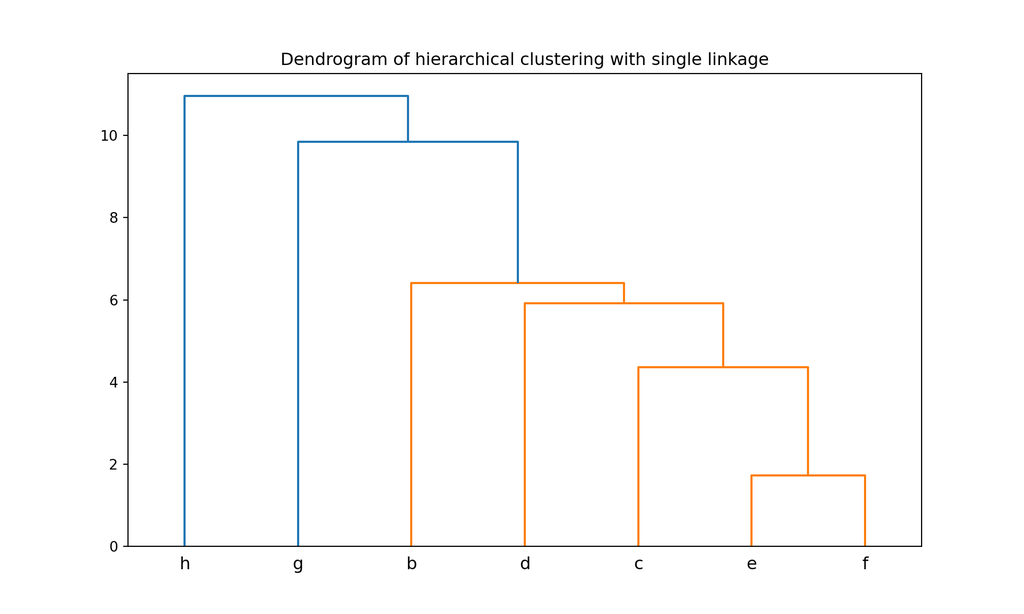

```python
plt.title('Dendrogram of hierarchical clustering with single linkage')
plt.show()
```

2. Determine whether a point is core based on eps = 6 and ‘minPts’ = 2. (Recall that a point p is a core point if at least ‘minPts’ points are within distance eps of it (including p).

```python
# determine core points
eps = 6
minPts = 2
core_points = []
for i in range(len(P4_df)):
    if sum(P4_df.iloc[i] <= eps) >= minPts:
        core_points.append(classes[i])

print("Core Points:",core_points)
```

Core Points: [‘b’, ‘c’, ‘d’, ‘e’, ‘f’, ‘g’, ‘h’]